# clusterProfiler GSEA JSON round trip

Run with fgsea, serialize with protsea, reconstruct, and plot

This article demonstrates the complete native GSEA exchange path. We run a pre-ranked analysis with `clusterProfiler::GSEA()` and its fgsea backend, serialize the resulting `gseaResult` with protsea, reconstruct it from JSON, verify the preserved data, and create clusterProfiler/enrichplot figures from the reconstructed object. Reconstruction does not rerun enrichment or permutation testing.

## Prepare a ranked list and gene sets

The example is deterministic and self-contained. The ranking contains 120 proteins. Two pathways occupy opposite ends of the ranking, while a third contains proteins from both ends.

```r
protein_ids <- sprintf("protein_%03d", seq_len(120))
ranked_scores <- seq(4, -4, length.out = length(protein_ids))
names(ranked_scores) <- protein_ids

term2gene <- data.frame(
  term = rep(c("TOP_PATHWAY", "BOTTOM_PATHWAY", "BOTH_ENDS"), each = 16),
  gene = c(
    protein_ids[1:16],
    protein_ids[105:120],
    protein_ids[c(1:8, 113:120)]
  )
)

term2name <- data.frame(
  term = c("TOP_PATHWAY", "BOTTOM_PATHWAY", "BOTH_ENDS"),
  name = c("Proteins at the top", "Proteins at the bottom", "Proteins at both ends")
)
```

## Run clusterProfiler with fgsea

`by = "fgsea"` selects the fgsea backend. The non-default exponent is useful here because the round trip must retain the weighting parameter used to reconstruct the running enrichment score.

```r
set.seed(42)
native <- clusterProfiler::GSEA(
  geneList = ranked_scores,
  exponent = 1.25,
  minGSSize = 5,
  maxGSSize = 30,
  pvalueCutoff = 1,
  TERM2GENE = term2gene,
  TERM2NAME = term2name,
  by = "fgsea",
  seed = TRUE,
  verbose = FALSE
)

native@result[, c("ID", "Description", "enrichmentScore", "NES", "p.adjust")]
```

```
                           ID            Description enrichmentScore       NES
TOP_PATHWAY       TOP_PATHWAY    Proteins at the top             1.0  3.011268
BOTTOM_PATHWAY BOTTOM_PATHWAY Proteins at the bottom            -1.0 -2.931947
BOTH_ENDS           BOTH_ENDS  Proteins at both ends             0.5  1.505634
                   p.adjust
TOP_PATHWAY    1.500000e-10
BOTTOM_PATHWAY 1.500000e-10
BOTH_ENDS      5.378486e-02
```

## Serialize and deserialize

`gsea_result_data()` creates the shared R representation. `write_gsea_result_json()` writes it as JSON for file exchange. The same JSON text can be stored directly in a MuData `uns` entry and passed to `decode_gsea_json()` without an intermediate file.

```r
document <- protsea::gsea_result_data(
  results = list(treatment_vs_control = native),
  category = "Example pathways",
  method = "fgsea"
)

json_path <- tempfile(fileext = ".json")
protsea::write_gsea_result_json(document, json_path)
json_text <- paste(readLines(json_path, warn = FALSE), collapse = "\n")

restored <- protsea::decode_gsea_json(json_text)[["treatment_vs_control"]][["Example pathways"]]

data.frame(
  Property = c("Result table", "Ranked list", "Gene sets", "GSEA parameters"),
  Equivalent = c(
    isTRUE(all.equal(restored@result, native@result)),
    isTRUE(all.equal(restored@geneList, native@geneList)),
    isTRUE(all.equal(restored@geneSets, native@geneSets)),
    isTRUE(all.equal(restored@params, native@params))
  )
)
```

```
         Property Equivalent
1    Result table       TRUE
2     Ranked list       TRUE
3       Gene sets       TRUE
4 GSEA parameters       TRUE
```

The JSON retains the complete typed result table, ordered ranking, complete gene sets, leading-edge identifiers, and the actual analysis parameters with their R storage types. This is enough for enrichplot to derive hit positions and running-score curves from the reconstructed object.

## Plot the reconstructed result

The following plots use `restored`, not the original `native` object.

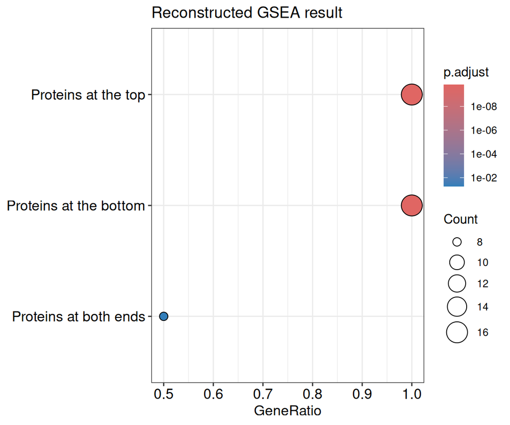

```r
enrichplot::dotplot(restored, showCategory = 3) +
  ggplot2::ggtitle("Reconstructed GSEA result")
```

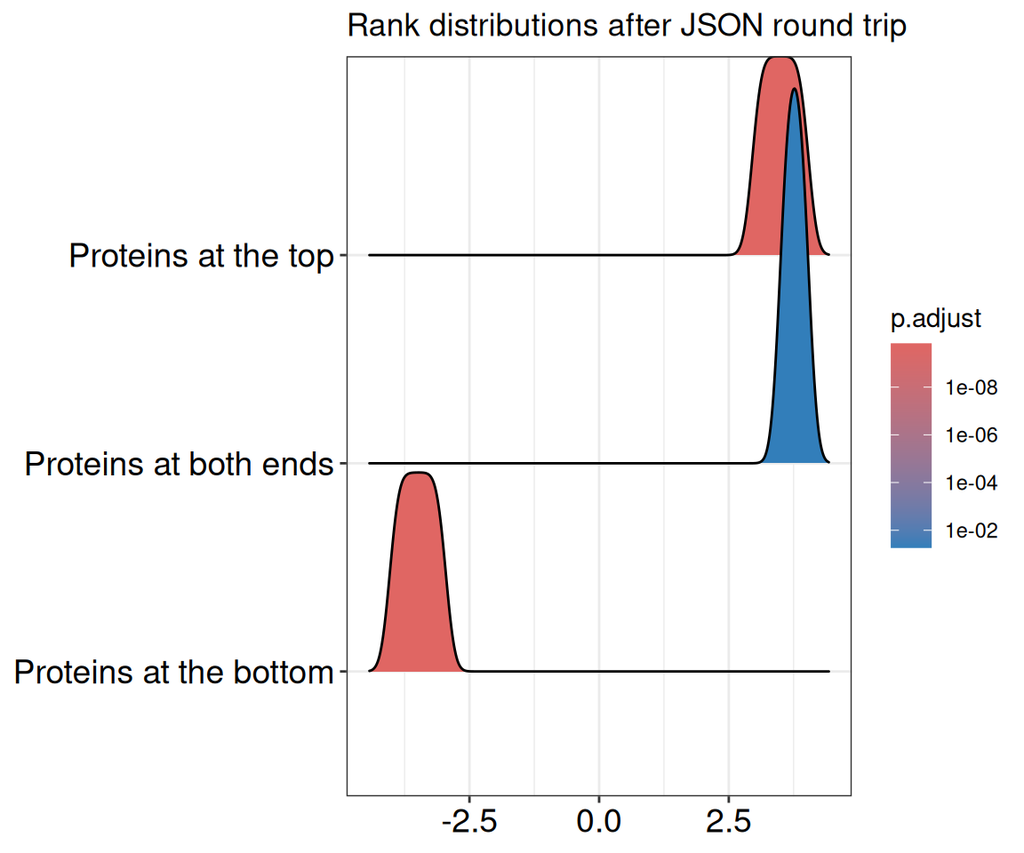

Figure 2: Rank-score distributions for the reconstructed pathway memberships.

```r
enrichplot::ridgeplot(restored, showCategory = 3) +
  ggplot2::ggtitle("Rank distributions after JSON round trip")
```

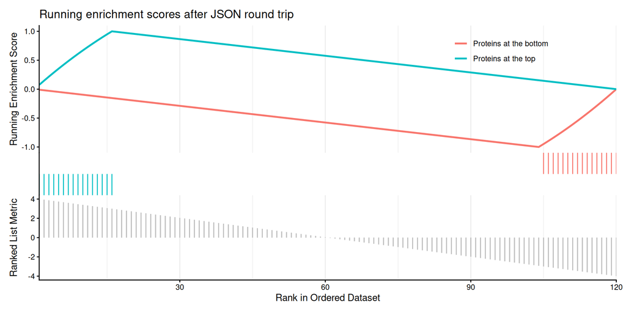

Figure 3: Running enrichment scores reconstructed from the retained ranking, gene sets, and exponent.

```r
enrichplot::gseaplot2(
  restored,
  geneSetID = c("TOP_PATHWAY", "BOTTOM_PATHWAY"),
  title = "Running enrichment scores after JSON round trip"
)
```

## What the JSON round trip supports

The native round trip retains ES, NES, raw and adjusted p-values, q-values, result-table types, full gene-set membership, leading edges, exact rank order including ties, and the weighting exponent. Permutation matrices are deliberately omitted because this format supports result exchange and plotting rather than resuming permutation calculations.